# Practical Machine Learning Course Project

Amrit D. Patel

Thursday, January 22, 2015

### Executive Summary

Using devices such as Jawbone Up, Nike FuelBand, and Fitbit it is now possible to collect a large amount of data about personal activity relatively inexpensively. These type of devices are part of the quantified self movement - a group of enthusiasts who take measurements about themselves regularly to improve their health, to find patterns in their behavior, or because they are tech geeks. One thing that people regularly do is quantify how much of a particular activity they do, but they rarely quantify how well they do it. In this project, data from accelerometers on the belt, forearm, arm, and dumbell of 6 participants is analyzed. They were asked to perform barbell lifts correctly and incorrectly in 5 different ways. More information is available from the website here: http://groupware.les.inf.puc-rio.br/har (see the section on the Weight Lifting Exercise Dataset); the data for this project can also be obtained at this website.

A prediction model was built to determine the type of barbell lift (within the 5 classes mentioned above) being performed using 55 different features. The selected model produced an estimated out-of-sample error of ~1% indicating that the model will perform with very high accuracy. However, from examining receiver operating characteristic curves, it is clear that certain barbell lift classes are easier to predict than others.

### Analysis

Set the working directory and load the training data:

```r
library(dplyr)
library(caret)

setwd("C:/Users/axp13/Dropbox/Coursera/Data Science/Machine Learning")
pmlTrainPre <- tbl_df(read.csv("pml-training.csv", stringsAsFactors=FALSE))
pmlTest <- tbl_df(read.csv("pml-testing.csv", stringsAsFactors=FALSE))
```

Determine the features available for training from the test dataset:

```r
pmlTest <- pmlTest[,colSums(is.na(pmlTest))<nrow(pmlTest)] # remove all columns where all values are 'NA';
                                                           # assuming these variables aren't useful
pmlTest <- pmlTest[-60] # remove the 'problem_id' column; only useful for submission phase of this project
pmlTest <- pmlTest %>% select(-X, -raw_timestamp_part_1, -cvtd_timestamp, -new_window) # remove unneeded descriptive variables
```

Perform basic data cleaning on training dataset so that it is consistent with the testing dataset:

```r
pmlTrainPre <-
pmlTrainPre %>% # select the entire dataset
filter(new_window == "no") %>% # only keep rows ending on the last timestep of the time "window"
select(-X, -raw_timestamp_part_1, -cvtd_timestamp, -new_window) # remove unneeded descriptive variables
```

Next, partition the training data into training and validation sets for cross-validation. Although it would be typical to specify the training set to be about 70% of the unpartitioned data (using the remaining data for the validation set), here 30% is specified in order to minimize runtime when fitting the model. It was found that 30% is reasonable after trying runs specifying both 10% and 20% for training set partitions (in-sample accuracy was ~85% and ~92%, respectively). In-sample accuracy increased to ~99% after the training set partition was set to 30%.

```r
inBuild <- createDataPartition(y=pmlTrainPre$classe, p=0.3, list=FALSE) # since the dataset is so large, use only a portion to minimize train runtime
pmlTrain<- pmlTrainPre[inBuild,] # specify the training data
pmlVal <- pmlTrainPre[-inBuild,] # specify the validation data
```

Remove unwanted variables from the training dataset:

```r
classe <- pmlTrain$classe # save the output variable
pmlTrain <- pmlTrain[, names(pmlTest)] # only keep columns available in testing dataset
pmlTrain <- tbl_df(cbind(pmlTrain, classe)) # add the output variable back to the dataset since it was removed in last statement
```

Train a model using random forests:

```r
nzv <- nearZeroVar(pmlTrain, saveMetrics=TRUE) # identify variables that won't be good predictors
nzv[nzv$nzv==TRUE,] # variables to remove
```

```
## [1] freqRatio     percentUnique zeroVar       nzv
## <0 rows> (or 0-length row.names)
```

It looks like including all selected variables has value. Now the model is fit…

```r
modFit <- train(classe ~ ., method="rf", prox=TRUE, data=pmlTrain)
modFit$finalModel # look at model confusion matrix
```

```
##
## Call:
##  randomForest(x = x, y = y, mtry = param$mtry, proximity = TRUE)
##                Type of random forest: classification
##                      Number of trees: 500
## No. of variables tried at each split: 30
##
##         OOB estimate of  error rate: 0.62%
## Confusion matrix:
##      A    B   C   D    E class.error
## A 1640    2   0   0    0 0.001218027
## B    8 1104   4   0    0 0.010752688
## C    0    8 997   1    0 0.008946322
## D    0    1   5 938    1 0.007407407
## E    0    2   0   4 1053 0.005665722
```

```r
modFit$times # look at execution times
```

```
## $everything
##    user  system elapsed
## 2907.27   15.49 2931.59
##
## $final
##    user  system elapsed
##   37.85    0.22   38.08
##
## $prediction
## [1] NA NA NA
```

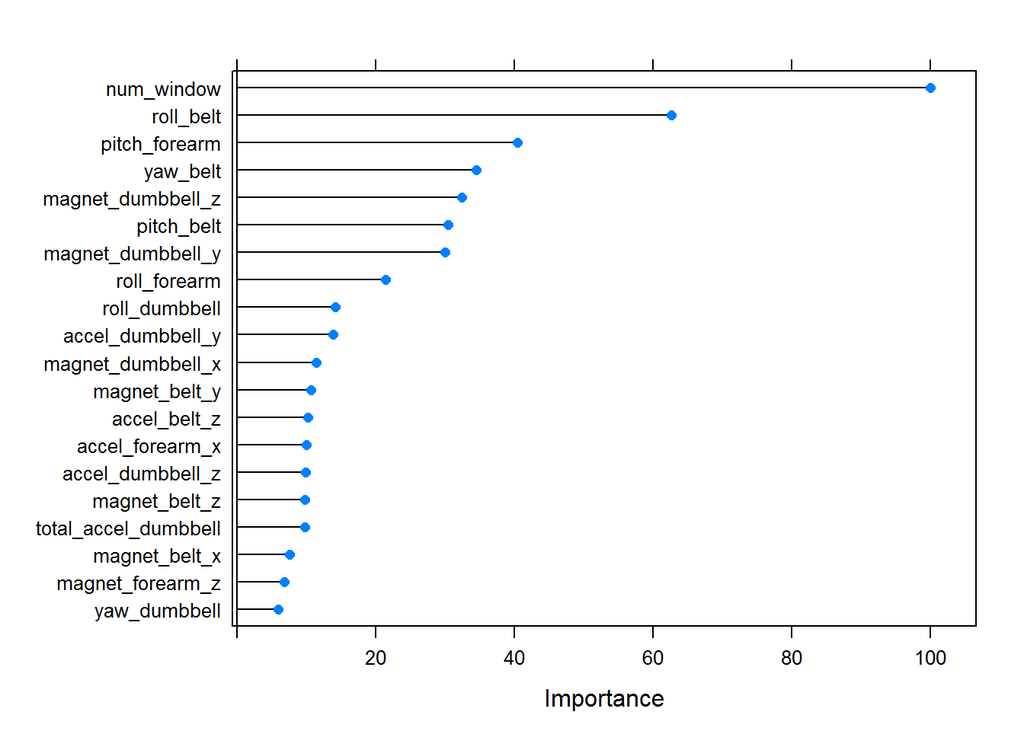

```r
modImp <- varImp(modFit) # look at variable importances
plot(modImp, top=20) # plot top variable importances
```

Let’s look at ROC curves for the different classes…

```
##
## Call:
## roc.default(response = pmlVal$classe, predictor = modFitProbs$A,     levels = rev(levels(pmlVal$classe)))
##
## Data: modFitProbs$A in 2469 controls (pmlVal$classe E) < 2202 cases (pmlVal$classe D).
## Area under the curve: 0.6635
```

```
##
## Call:
## roc.default(response = pmlVal$classe, predictor = modFitProbs$B,     levels = rev(levels(pmlVal$classe)))
##
## Data: modFitProbs$B in 2469 controls (pmlVal$classe E) < 2202 cases (pmlVal$classe D).
## Area under the curve: 0.626
```

```
##
## Call:
## roc.default(response = pmlVal$classe, predictor = modFitProbs$C,     levels = rev(levels(pmlVal$classe)))
##
## Data: modFitProbs$C in 2469 controls (pmlVal$classe E) < 2202 cases (pmlVal$classe D).
## Area under the curve: 0.6701
```

```
##
## Call:
## roc.default(response = pmlVal$classe, predictor = modFitProbs$D,     levels = rev(levels(pmlVal$classe)))
##
## Data: modFitProbs$D in 2469 controls (pmlVal$classe E) < 2202 cases (pmlVal$classe D).
## Area under the curve: 0.9997
```

```
##
## Call:
## roc.default(response = pmlVal$classe, predictor = modFitProbs$E,     levels = rev(levels(pmlVal$classe)))
##
## Data: modFitProbs$E in 2469 controls (pmlVal$classe E) > 2202 cases (pmlVal$classe D).
## Area under the curve: 1
```

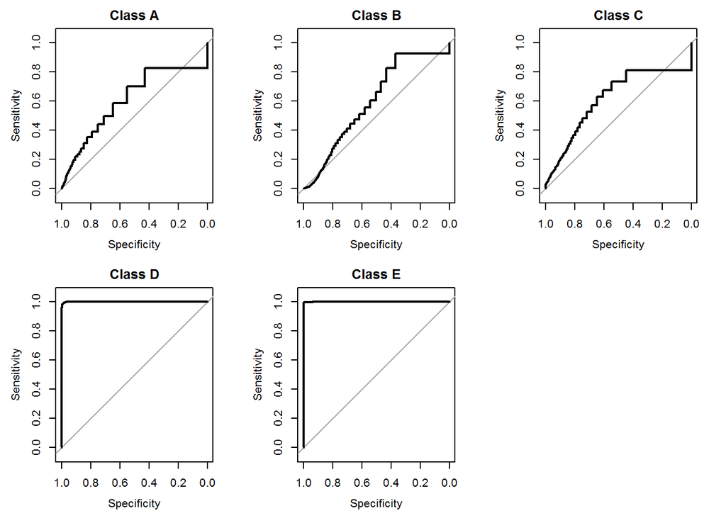

```r
library(pROC) # useful for displaying and analyzing ROC curves

modFitProbs <- predict(modFit, pmlVal, type = "prob") # get prediction probabilities

# Build ROC objects (for each class type) for plotting
levels(pmlVal$classe) <- c("A", "B", "C", "D", "E") # specify factor levels
modFitROCa <- roc(predictor = modFitProbs$A, response = pmlVal$classe, levels = rev(levels(pmlVal$classe)))
modFitROCb <- roc(predictor = modFitProbs$B, response = pmlVal$classe, levels = rev(levels(pmlVal$classe)))
modFitROCc <- roc(predictor = modFitProbs$C, response = pmlVal$classe, levels = rev(levels(pmlVal$classe)))
modFitROCd <- roc(predictor = modFitProbs$D, response = pmlVal$classe, levels = rev(levels(pmlVal$classe)))
modFitROCe <- roc(predictor = modFitProbs$E, response = pmlVal$classe, levels = rev(levels(pmlVal$classe)))
```

It appears that Classes D and E will be the easiest to predict based on the area under the respective curves. Now, perform cross-validation:

```r
pmlVal <- pmlVal[, names(pmlTrain)] # only keep columns available in training dataset
confMat <- confusionMatrix(table(predict(modFit, pmlVal), pmlVal$classe)) # check accuracy and kappa in the validation set
confMat
```

```
## Confusion Matrix and Statistics
##
##
##        A    B    C    D    E
##   A 3829   29    0    1    0
##   B    0 2541   25    1    2
##   C    0   26 2320   30    0
##   D    0    6    1 2169    8
##   E    0    0    0    1 2459
##
## Overall Statistics
##
##                Accuracy : 0.9903
##                  95% CI : (0.9885, 0.9919)
##     No Information Rate : 0.2847
##     P-Value [Acc > NIR] : < 2.2e-16
##
##                   Kappa : 0.9878
##  Mcnemar's Test P-Value : NA
##
## Statistics by Class:
##
##                      Class: A Class: B Class: C Class: D Class: E
## Sensitivity            1.0000   0.9766   0.9889   0.9850   0.9959
## Specificity            0.9969   0.9974   0.9950   0.9987   0.9999
## Pos Pred Value         0.9922   0.9891   0.9764   0.9931   0.9996
## Neg Pred Value         1.0000   0.9944   0.9977   0.9971   0.9991
## Prevalence             0.2847   0.1935   0.1744   0.1637   0.1836
## Detection Rate         0.2847   0.1890   0.1725   0.1613   0.1829
## Detection Prevalence   0.2870   0.1910   0.1767   0.1624   0.1829
## Balanced Accuracy      0.9984   0.9870   0.9919   0.9918   0.9979
```

### Conclusion

Although this model took a significant time to train (~1 hour), the ~1% out-of-sample error (see accuracy and kappa in confusion matrix output above) achieved with the relatively large validation set is excellent.

Potential improvements:

- Use variable importances from the plot above to determine a model with fewer variables to make interpretation simpler
- Explore other prediction models that are less computationally intensive and that could still produce low out-of-sample error